# Bayesian Computation with R

This notebook was made with ‘Bayesian Computation with R’ by Jim Albert as reference. This notebook is for personal use only.

# Ch.4 Multiparameter models

In this chapter, we describe the use of R to summarize Bayesian models with several unknown parameters. In learning about parameters of a normal population or multinomial parameters, posterior inference is accomplished by simulating from distributions of standard forms. Once a simulated sample is obtained from the joint posterior, it is straightforward to perform transformations on these simulated draws to learn about any function of the parameters. We next consider estimating the parameters of a simple logistic regression model. Although the posterior distribution does not have a simple functional form, it can be summarized by computing the density on a fine grid of points. A common inference problem is to compare two proportions in a $2 \times 2$ contingency table. We illustrate the computation of the posterior probability that one proportion exceeds the second proportion in the situation in which one believes a priori that the proportions are dependent.

## Normal data with both parameters *unknown*

A standard inference problem is to learn about a normal population where both the mean and variance are unknown. To illustrate Bayesian computation for this problem, suppose we are interested in learning about the distribution of completion times for men between ages 20 and 29 who are running the New York Marathon. We observe the times $y_{1}, \cdots, y_{20}$ in minutes for 20 runners, and we assume they represent a random sample from an $N(\mu,\sigma)$ distribution. If we assume the standard noninformative prior $g(\mu,\sigma^{2}) \propto 1/\sigma^{2}$, then the posterior density of the mean and variance is given by

$$g(\mu, \sigma^{2}|y) \propto \frac{1}{(\sigma^{2})^{\frac{n}{2} + 1}}exp\left ( -\frac{1}{2\sigma^{2}}(S + n(\mu - \bar{y})^{2}) \right ),$$

where $n$ is the sample size, $\bar{y}$ is the sample mean, and $S = \sum_{i=1}^{n}(y_{i}-\bar{y})^{2}$.

This joint posterior has the familiar normal/inverse chi-square form where

- the posterior of $\mu$ conditional on $\sigma^{2}$ is distributed as $N(\bar{y}, \sigma/\sqrt{n})$
- the marginal posterior of $\sigma^{2}$ is distributed as $S_{\chi_{n-1}^{-2}}$, where $\chi_{v}^{-2}$ denotes an inverse chi-square distribution with $v$ degrees of freedom

We first use R to construct a contour plot of the joint posterior density for this example. We read in the data *marathontimes* from the *LearnBayes* package; we can use the variable *time* that contains the vector of running times.

The R function normchi2post() in the *LearnBayes* package computes the logarithm of the joint posterior density of $(\mu,\sigma^{2})$. We also use a function mycontour() in the *LearnBayes* package that facilitates the use of the R contour() command. There are four inputs to mycontour(): the name of the function that defines the log density, a vector with the values (xlo, xhi, ylo, and yhi) that define the rectangle where the density is to be graphed, the data used in the function for the log density, and any optional parameters used with contour.

The function produces a contour graph, where the contour lines are drawn at 10%, 1%, and 0.1% of the maximum value of the posterior density over the grid.

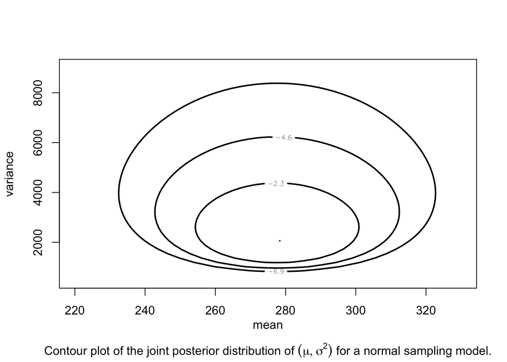

```r
library(latex2exp)  # for TeX()
library(LearnBayes)  # for marathontimes data, normchi2post(), and mycontour()
data(marathontimes)
mt <- marathontimes

d <- mycontour(normchi2post, c(220, 330, 500, 9000), mt$time, xlab="mean\n", ylab="variance", sub=TeX("Contour plot of the joint posterior distribution of $(\\mu, \\sigma^{2})$ for a normal sampling model."))
```

It is convenient to summarize this posterior distribution by simulation. One can simulate a value of $(\mu, \sigma^{2})$ from the joint posterior by first simulating $\sigma^{2}$ from an $S_{\chi_{n-1}^{-2}}$ distribution and then simulating $\mu$ from the $N(\bar{y}, \sigma/\sqrt{n})$ distribution.

In the following R output, we first simulate a sample of size 1000 from the chi-square distribution using the function rchisq(). Then simulated draws of the “scale times inverse chi-square” distribution of the variance $\sigma^{2}$ are obtained by transforming the chi-square draws. Finally, simulated draws of the mean $\mu$ are obtained using the function rnorm().

```r
S = sum((mt$time - mean(mt$time))^2)  # sample variance
n = length(mt$time)
sigma2 = S/rchisq(1000, n-1)
mu = rnorm(1000, mean=mean(mt$time), sd=sqrt(sigma2)/sqrt(n))
```

The function normpostsim() in the *LearnBayes* package can also implement this simulation algorithm.

We display the simulated sampled values of $(\mu, \sigma^{2})$ on top of the contour plot of the distribution we saw previously.

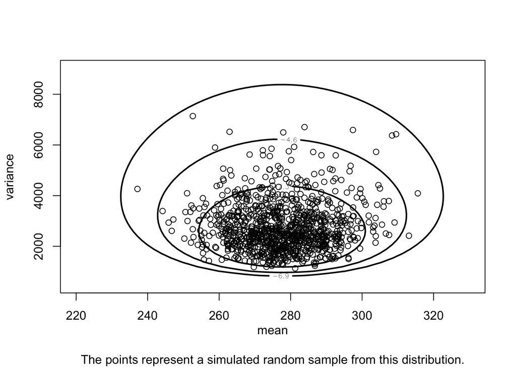

```r
d <- mycontour(normchi2post, c(220, 330, 500, 9000), mt$time, xlab="mean\n", ylab="variance", sub="The points represent a simulated random sample from this distribution.")
points(mu, sigma2)
```

Inferences about the parameters or functions of the parameters are available from the simulated sample. To construct a 95% interval estimate for the mean $\mu$, we use the R quantile function to find percentiles of the simulated sample of $\mu$.

```r
quantile(mu, c(0.025, 0.975))
```

```
##     2.5%    97.5%
## 255.4564 300.1054
```

Suppose we are interested in learning about the standard deviation $\sigma$ that describes the spread of the population of marathon running times. To obtain a sample of the posterior of $\sigma$, we take square roots of the simulated draws of $\sigma^{2}$.

```r
quantile(sqrt(sigma2), c(0.025, 0.975))
```

```
##     2.5%    97.5%
## 37.87191 71.09277
```

## A multinomial model

Gelman et al. (2003) describe a sample survey conducted by CBS News before the 1988 presidential election. A total of 1447 adults were polled to indicate their preference; $y_{1} = 727$ supported George Bush, $y_{2} = 583$ supported Michael Dukakis, and $y_{3} = 137$ supported other candidates or expressed no opinion. The counts $y_{1}$, $y_{2}$, and $y_{3}$ are assumed to have a multinomial distribution with sample size $n$ and respective probabilities $\theta_{1}$, $\theta_{2}$, and $\theta_{3}$. If a uniform prior distribution is assigned to the multinomial vector $\theta = (\theta_{1},\theta_{2},\theta_{3})$, then the posterior distribution of $\theta$ is proportional to

$$g(\theta) = \theta_{1}^{y_{1}}\theta_{2}^{y_{2}}\theta_{3}^{y_{3}},$$

which is recognized as a Dirichlet distribution with parameters $(y_{1} + 1, y_{2} + 1, y_{3} + 1)$. The focus is to compare the proportions of voters for Bush and Dukakis by considering the difference $\theta_{1} − \theta_{2}$.

The summarization of the Dirichlet posterior distribution is again conveniently done by simulation. Although the base R package does not have a function to simulate Dirichlet variates, it is easy to write a function to simulate this distribution based on the fact that if $W_{1} , W_{2} , W_{3}$ are independently distributed from $gamma(\alpha_{1},1), \ gamma(\alpha_{2},1), \ gamma(\alpha_{3},1)$ distributions and $T = W_{1} + W_{2} + W_{3}$, then the distribution of the proportions $(W_{1}/T,W_{2}/T,W_{3}/T)$ has a $Dirichlet(\alpha_{1},\alpha_{2},\alpha_{3})$ distribution.

The R function rdirichlet() in the package *LearnBayes* uses this transformation of random variates to simulate draws of a Dirichlet distribution. One thousand vectors $\theta$ are simulated and stored in the matrix *theta*.

```r
alpha <- c(728, 584, 138)
theta <- rdirichlet(1000, alpha)
```

Since we are interested in comparing the proportions for Bush and Dukakis, we focus on the difference $\theta_{1} - \theta_{2}$. Let’s draw a histogram of the simulated draws of this difference.

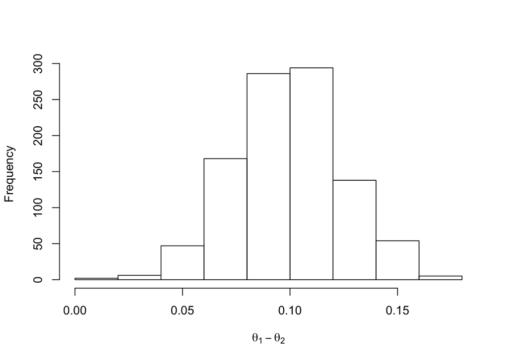

Histogram of simulated sample of the marginal posterior distribution of $\theta_{1} - \theta_{2}$ for the multinomial sampling example.

```r
library(latex2exp)  # for TeX()
hist(theta[,1] - theta[,2], main="", xlab=TeX("$\\theta_{1} - \\theta_{2}$"))
```

Note that all of the mass of this distribution is on positive values, indicating that there is strong evidence that the proportion of voters for Bush exceeds the proportion for Dukakis.